# Monte Carlo

# What are we trying to do

MCMC aims to let us randomly sample from a distribution that we can’t model directly. We must have access to som function $f$ that is proportional to the probability distribution we are trying to sample.

# The Metropolis-Hastings algorithm

1. Start in a random point of the distribution
2. Randomly select a new candidate location from the available states. In the case of a continuous distribution this is anywhere, in the case of a Markov chain this will be determined by the avaiilable state transitions. There may or may not need to be a probability distribution associated with this selection process depending on the model.
3. Compute the value of $f$ for the new location and compare it to $f$ at the current location. The ratio of $f_{t+1}$ to $f_{t}$ becomes the “acceptance probability”.
4. Generate a random number between 0 and 1. If this is less than or equal to the “acceptance probability”, move to the new state. Otherwise remain where you are.
5. At each step, record which state you are in.

Although the value of the distribution itself is not necessarily known, this approach means you will spend time in each state relative to its value of $f$.

# Demo - simulating the Beta distribution

This function takes `n_steps` through the Metropolis-Hastings algorithm and returns a vector of the values of the states visited.

```r
simulate_beta <- function(n_steps, a, b) {
  states <- numeric(n_steps)
  current_state <- runif(1)

  for (t in seq_len(n_steps)) {
    # Calculate value of f at this state
    here <- stats::dbeta(current_state, a, b)
    # Record current state
    states[t] <- current_state
    # Randomly select new target state
    proposed_state <- runif(1)
    # Calculate "height" of proposed state
    there <- dbeta(proposed_state, a, b)
    # Calculate the ratio of heights
    acceptance_criteria <- there / here
    # Randomly transition
    if (runif(1) < acceptance_criteria) {
      current_state <- proposed_state
    }
  }
  states
}
```

We can use the function above to see how increasing the sample size increases the goodness of fit of our modelled distribution to the true distribution.

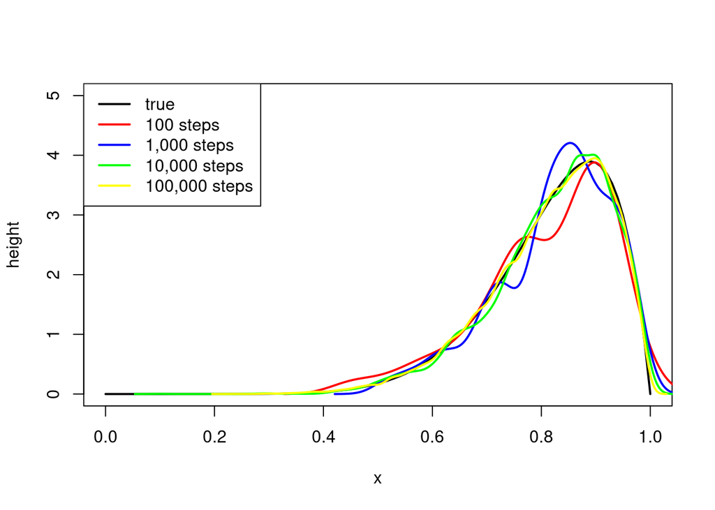

```r
x <- seq(0, 1, 0.01)
true_beta_y <- dbeta(x, 9, 2)
sim_beta_100 <- simulate_beta(100, 9, 2)
sim_beta_1000 <- simulate_beta(1000, 9, 2)
sim_beta_10000 <- simulate_beta(10000, 9, 2)
sim_beta_100000 <- simulate_beta(100000, 9, 2)

plot(x, true_beta_y, type = "l", col = "black", ylim = c(0, 5), ylab = "height", lwd = 2)
lines(density(sim_beta_100), type = "l", col = "red", lwd = 2)
lines(density(sim_beta_1000), type = "l", col = "blue", lwd = 2)
lines(density(sim_beta_10000), type = "l", col = "green", lwd = 2)
lines(density(sim_beta_100000), type = "l", col = "yellow", lwd = 2)
legend(
  "topleft",
  legend = c("true", "100 steps", "1,000 steps", "10,000 steps", "100,000 steps"),
  col = c("black", "red", "blue", "green", "yellow"),
  lty = 1,
  lwd = 2
)
```